# Math&146 Lab #4

N. Paterno

In this lab we will learn how to calculate the descriptive statistics for a numeric variable. We’ll be using the *teacher* data set from the *openintro* package. As usual, let’s look at the data.

```r
glimpse(teacher)
```

```
## Rows: 71
## Columns: 8
## $ id         <fct> 01, 02, 03, 04, 05, 06, 07, 08, 09, 11, 12, 13, 14, 15, ...
## $ degree     <fct> BA, MA, MA, BA, BA, BA, BA, MA, BA, BA, BA, BA, BA, BA, ...
## $ fte        <fct> 1, 1, 1, 1, 1, 1, 1, 1, 1, 1, 1, 1, 1, 1, 1, 1, 1, 1, 1,...
## $ years      <dbl> 5.0, 15.0, 16.0, 10.0, 26.0, 28.5, 12.0, 32.0, 25.0, 12....
## $ base       <int> 45388, 60649, 60649, 54466, 65360, 65360, 58097, 68230, ...
## $ fica       <dbl> 3472.18, 4639.65, 4639.65, 4166.65, 5000.04, 5000.04, 44...
## $ retirement <dbl> 7688.73, 10273.94, 10273.94, 9226.54, 11071.98, 11071.98...
## $ total      <dbl> 56548.91, 75562.59, 75562.59, 67859.19, 81432.02, 81432....
```

## Mean, Standard Deviation and Variance

To calculate mean, standard deviation and variance, we’ll use the *summarize* function from lab #2 in combination with the functions *mean*, *sd* and *var*. For the examples, we’ll focus on the *total* variable.

```r
teacher_summary_full <- teacher %>%
  summarize(mean_total = mean(total),
            sd_total = sd(total),
            var_total = var(total))

glimpse(teacher_summary_full)
```

```
## Rows: 1
## Columns: 3
## $ mean_total <dbl> 70288.64
## $ sd_total   <dbl> 12439.34
## $ var_total  <dbl> 154737082
```

## Five Number Summary

There are two ways we can calculate the five number summary: as a whole or individually.

### As a Whole

```r
fivenum(teacher$total)
```

```
## [1] 24793.41 63757.69 74646.85 81432.02 85007.76
```

### Individually

To calculate the five number summary individually, we need to *summarize* the data frame and use an index to specify a position in our vector.

```r
teacher_fivenum <- teacher %>%
  summarize(min = fivenum(total)[1],
            q1 = fivenum(total)[2],
            md = fivenum(total)[3],
            q3 = fivenum(total)[4],
            max = fivenum(total)[5])

glimpse(teacher_fivenum)
```

```
## Rows: 1
## Columns: 5
## $ min <dbl> 24793.41
## $ q1  <dbl> 63757.69
## $ md  <dbl> 74646.85
## $ q3  <dbl> 81432.02
## $ max <dbl> 85007.76
```

Based on the mean and median, the data appears to be skewed left. We can confirm this with a quick histogram.

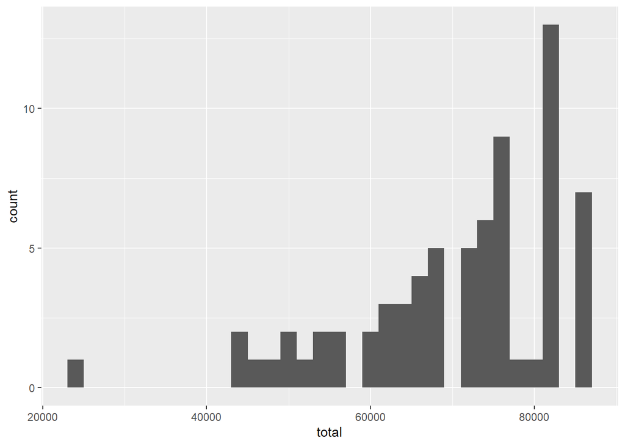

```r
ggplot(teacher,
       aes(total))+
  geom_histogram(binwidth = 2000)
```

## Assignment

In a script file:

1. Calculate the mean, standard deviation and variance for the *retirement* variable.
2. Calculate the five number summary for the *retirement* variable as whole and individually.

Save your work in a script file called: LastName_lab4. For example, my assignment file would be Paterno_lab4.R

## Extra Material

If we were doing a more detailed analysis, we may want to discover what role experience and college degree have in determining someones salary. Later in the quarter we will learn specific statistical tests that will do this for us. For now, we can do some calculations to get a rough idea.

### Grouping by College Degree

```r
teacher_summary_degree <- teacher %>%
  group_by(degree) %>%
  summarize(mean_total = mean(total),
            sd_total = sd(total),
            var_total = var(total))

glimpse(teacher_summary_degree)
```

```
## Rows: 2
## Columns: 4
## $ degree     <fct> BA, MA
## $ mean_total <dbl> 70090.72, 70529.85
## $ sd_total   <dbl> 12302.62, 12797.10
## $ var_total  <dbl> 151354440, 163765722
```

```r
teacher_fivenum_degree <- teacher %>%
  group_by(degree) %>%
  summarize(min = fivenum(total)[1],
            q1 = fivenum(total)[2],
            md = fivenum(total)[3],
            q3 = fivenum(total)[4],
            max = fivenum(total)[5])

glimpse(teacher_fivenum_degree)
```

```
## Rows: 2
## Columns: 6
## $ degree <fct> BA, MA
## $ min    <dbl> 44138.50, 24793.41
## $ q1     <dbl> 61640.28, 63757.69
## $ md     <dbl> 74646.85, 72609.81
## $ q3     <dbl> 81432.02, 79105.30
## $ max    <dbl> 81432.02, 85007.76
```

### Grouping by Experience

```r
teacher_summary_year <- teacher %>%
  group_by(years) %>%
  summarize(mean_total = mean(total),
            sd_total = sd(total),
            var_total = var(total))

glimpse(teacher_summary_year)
```

```
## Rows: 38
## Columns: 4
## $ years      <dbl> 0.0, 1.0, 2.0, 3.0, 4.0, 5.0, 5.5, 7.0, 7.5, 8.0, 9.0, 1...
## $ mean_total <dbl> 44138.50, 35569.82, 50249.01, 51941.98, 55480.55, 56548....
## $ sd_total   <dbl> 0.0000, 15240.1452, 2402.4448, 2052.9363, 1683.5647, NA,...
## $ var_total  <dbl> 0.0, 232262025.0, 5771741.0, 4214547.5, 2834390.0, NA, N...
```

```r
teacher_fivenum_year <- teacher %>%
  group_by(years) %>%
  summarize(min = fivenum(total)[1],
            q1 = fivenum(total)[2],
            md = fivenum(total)[3],
            q3 = fivenum(total)[4],
            max = fivenum(total)[5])

glimpse(teacher_fivenum_year)
```

```
## Rows: 38
## Columns: 6
## $ years <dbl> 0.0, 1.0, 2.0, 3.0, 4.0, 5.0, 5.5, 7.0, 7.5, 8.0, 9.0, 10.0, ...
## $ min   <dbl> 44138.50, 24793.41, 48550.23, 50756.72, 54290.09, 56548.91, 6...
## $ q1    <dbl> 44138.50, 24793.41, 48550.23, 50756.72, 54290.09, 56548.91, 6...
## $ md    <dbl> 44138.50, 35569.82, 50249.01, 50756.72, 55480.55, 56548.91, 6...
## $ q3    <dbl> 44138.50, 46346.23, 51947.80, 52534.62, 56671.01, 56548.91, 6...
## $ max   <dbl> 44138.50, 46346.23, 51947.80, 54312.51, 56671.01, 56548.91, 6...
```

We can also visually separate our ggplot image using color.

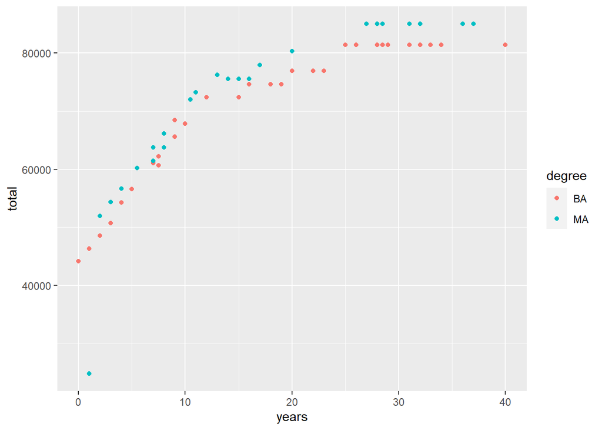

```r
ggplot(teacher,
       aes(years, total, color = degree))+
  geom_point()
```